# Assignment 3

```r
library(tidyverse)
library(ggplot2)
library(viridis)
library(ggthemes)
library(wesanderson)
library(skimr)
library(cowplot)
library(flexdashboard)
library(shiny)
```

I aim to explore the relationship between citizenship, class, and race. I have updated the csv file from the last assignment, to mutate all the race variables into one.

```r
citizenship_data <- read_csv("Citizenship-class-race-updated.csv")
attach(citizenship_data)
```

Quick reminder of the variables:

| Name | Code | Type |
| --- | --- | --- |
| Age | AGEP | cont |
| Race | RACE | catg |
| Employment | ESR | catg |
| Education | SCHL | catg |
| Income | WAGP | cont |
| Year of Entry | YOEP | cont |
| Period of Naturalization | years_to_nat | cont |

```r
skimr::skim(citizenship_data)
```

Data summary

| Name | citizenship_data |
| --- | --- |
| Number of rows | 51410 |
| Number of columns | 8 |
| _______________________ |  |
| Column type frequency: |  |
| character | 3 |
| numeric | 5 |
| ________________________ |  |
| Group variables | None |

**Variable type: character**

| skim_variable | n_missing | complete_rate | min | max | empty | n_unique | whitespace |
| --- | --- | --- | --- | --- | --- | --- | --- |
| RACE | 0 | 1 | 5 | 33 | 0 | 6 | 0 |
| ESR_label | 0 | 1 | 10 | 45 | 0 | 7 | 0 |
| SCHL_label | 0 | 1 | 7 | 46 | 0 | 25 | 0 |

**Variable type: numeric**

| skim_variable | n_missing | complete_rate | mean | sd | p0 | p25 | p50 | p75 | p100 | hist |
| --- | --- | --- | --- | --- | --- | --- | --- | --- | --- | --- |
| X1 | 0 | 1 | 25705.50 | 14840.93 | 1 | 12853.25 | 25705.5 | 38557.75 | 51410 | ▇▇▇▇▇ |
| AGEP | 0 | 1 | 54.91 | 16.29 | 0 | 44.00 | 55.0 | 66.00 | 94 | ▁▃▇▇▂ |
| WAGP | 0 | 1 | 38430.85 | 68299.80 | -1 | 0.00 | 12500.0 | 52000.00 | 565000 | ▇▁▁▁▁ |
| YOEP | 0 | 1 | 1985.60 | 13.90 | 1929 | 1977.00 | 1986.0 | 1996.00 | 2017 | ▁▁▆▇▃ |
| years_to_nat | 0 | 1 | 13.70 | 9.73 | 1 | 6.00 | 11.0 | 19.00 | 84 | ▇▂▁▁▁ |

## Correlation tests for the continuous variables

I will run three correlation tests for age and income, age and period of naturalization, income and period of naturalization.

### Age and Income correlation test

```r
correlation_age_income <- cor.test(citizenship_data$AGEP, citizenship_data$WAGP)
correlation_age_income
```

```
##
##  Pearson's product-moment correlation
##
## data:  citizenship_data$AGEP and citizenship_data$WAGP
## t = -45.144, df = 51408, p-value < 2.2e-16
## alternative hypothesis: true correlation is not equal to 0
## 95 percent confidence interval:
##  -0.2035730 -0.1869438
## sample estimates:
##        cor
## -0.1952724
```

Let’s visualize the results in ggplot.

```r
summary(WAGP)
```

```
##    Min. 1st Qu.  Median    Mean 3rd Qu.    Max.
##      -1       0   12500   38431   52000  565000
```

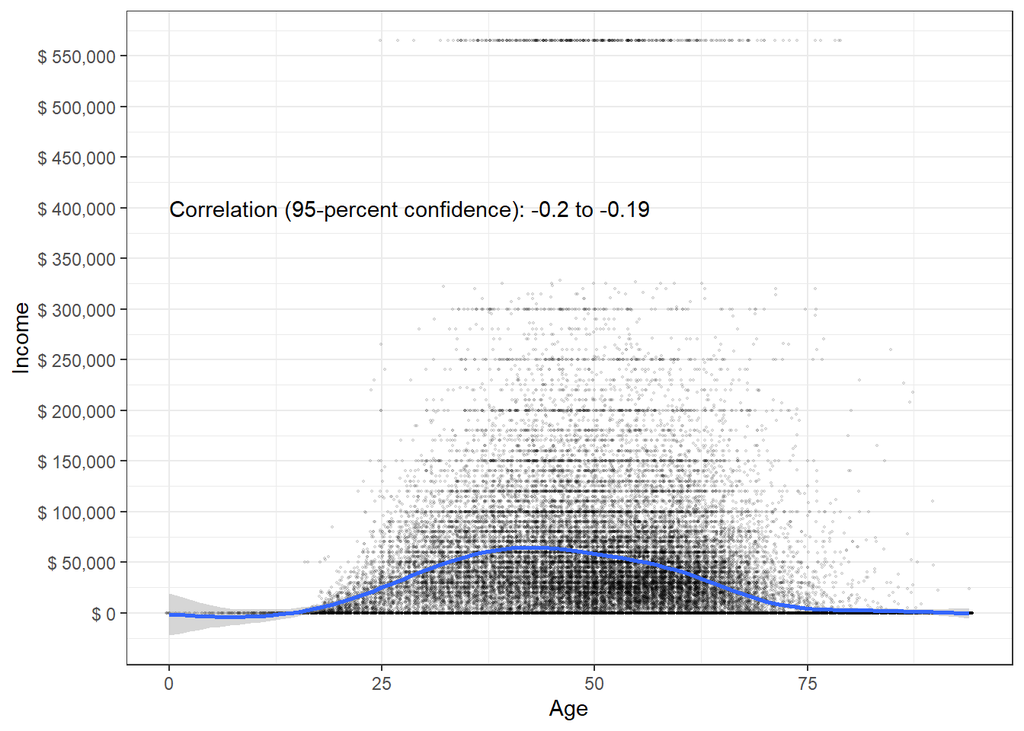

```r
options(scipen = 999)
ggplot(citizenship_data, aes(x = AGEP, y = WAGP)) +
  geom_point(size = 0.3, alpha = 0.1, position = "jitter") +
  geom_smooth() +
  theme_bw() +
  scale_x_continuous(name = "Age") +
 scale_y_continuous(name = "Income",
                     breaks = seq(0, 565000, by = 50000),
                     labels = paste("$",
                                    prettyNum(seq(0, 565000, by = 50000),
                                              big.mark = ","))) +
  annotate(geom = "text", x = 0, y = 400000,
           label = paste("Correlation (95-percent confidence):",
                         prettyNum(correlation_age_income$conf.int[1], digits = 2),
                         "to",
                         prettyNum(correlation_age_income$conf.int[2], digits = 2)),
           hjust = 0)
```

### Age and Period of naturalization correlation test

```r
correlation_age_periodnat <- cor.test(citizenship_data$years_to_nat, citizenship_data$AGEP)
correlation_age_periodnat
```

```
##
##  Pearson's product-moment correlation
##
## data:  citizenship_data$years_to_nat and citizenship_data$AGEP
## t = 44.131, df = 51408, p-value < 0.00000000000000022
## alternative hypothesis: true correlation is not equal to 0
## 95 percent confidence interval:
##  0.1827121 0.1993695
## sample estimates:
##       cor
## 0.1910545
```

```r
summary(years_to_nat)
```

```
##    Min. 1st Qu.  Median    Mean 3rd Qu.    Max.
##     1.0     6.0    11.0    13.7    19.0    84.0
```

[figure not shown]

```r
ggplot(citizenship_data, aes(x = years_to_nat, y = AGEP)) +
  geom_point(size = 0.3, alpha = 0.1, position = "jitter") +
  geom_smooth() +
  theme_bw() +
  scale_x_continuous(name = "Period of naturalization (in years)") +
 scale_y_continuous(name = "Age") +
  annotate(geom = "text", x = 0, y = 100,
           label = paste("Correlation (95-percent confidence):",
                         prettyNum(correlation_age_income$conf.int[1], digits = 2),
                         "to",
                         prettyNum(correlation_age_income$conf.int[2], digits = 2)),
           hjust = 0)
```

### Income and Period of Naturalization

```r
correlation_income_period_nat <- cor.test(citizenship_data$years_to_nat, citizenship_data$WAGP)
correlation_income_period_nat
```

```
##
##  Pearson's product-moment correlation
##
## data:  citizenship_data$years_to_nat and citizenship_data$WAGP
## t = -16.861, df = 51408, p-value < 0.00000000000000022
## alternative hypothesis: true correlation is not equal to 0
## 95 percent confidence interval:
##  -0.08275238 -0.06555900
## sample estimates:
##        cor
## -0.0741612
```

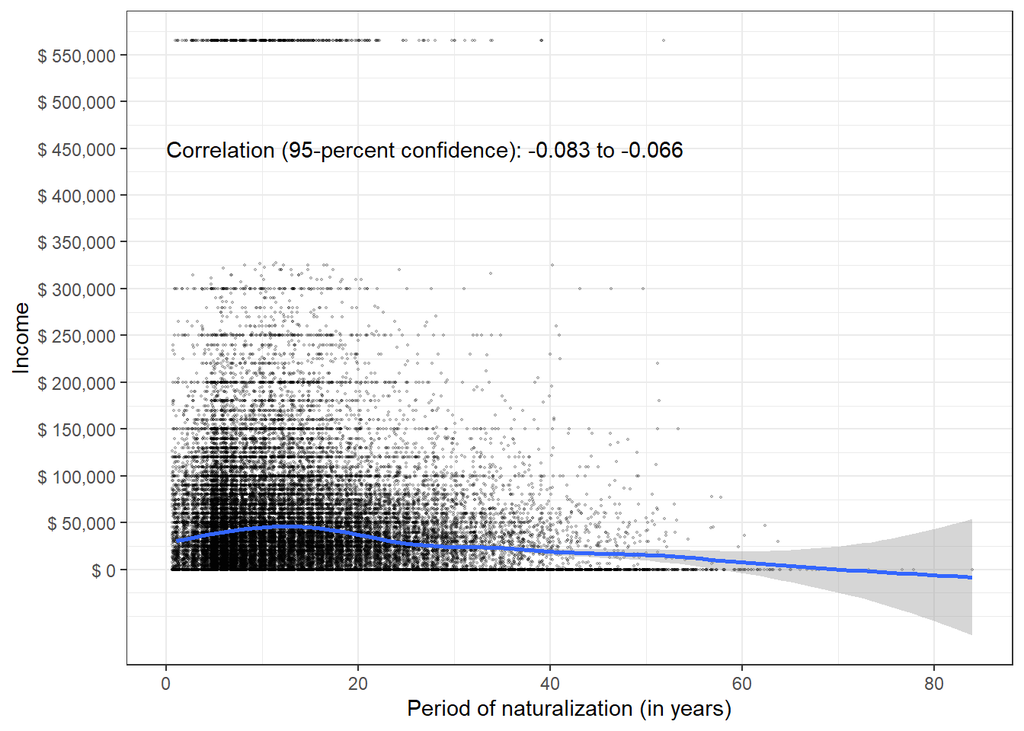

```r
options(scipen = 999)
ggplot(citizenship_data, aes(x = years_to_nat, y = WAGP)) +
  geom_point(size = 0.3, alpha = 0.2, position = "jitter") +
  geom_smooth() +
  theme_bw() +
  scale_x_continuous(name = "Period of naturalization (in years)") +
 scale_y_continuous(name = "Income",
                     breaks = seq(0, 565000, by = 50000),
                     labels = paste("$",
                                    prettyNum(seq(0, 565000, by = 50000),
                                              big.mark = ","))) +
  annotate(geom = "text", x = 0, y = 450000,
           label = paste("Correlation (95-percent confidence):",
                         prettyNum(correlation_income_period_nat$conf.int[1], digits = 2),
                         "to",
                         prettyNum(correlation_income_period_nat$conf.int[2], digits = 2)),
           hjust = 0)
```

## Relationship of categorical variables and continuous variables

I will run ANOVA tests for race and income, race and period of naturalization, race and age, income and education, period of naturalization and education, income and employment, period of naturalization and employment.

### Race and Income

```r
anova_race_income <- aov(WAGP ~ RACE, data = citizenship_data)

summary(anova_race_income)
```

```
##                Df          Sum Sq      Mean Sq F value              Pr(>F)
## RACE            5   2627933149710 525586629942   113.9 <0.0000000000000002 ***
## Residuals   51404 237187998583692   4614193420
## ---
## Signif. codes:  0 '***' 0.001 '**' 0.01 '*' 0.05 '.' 0.1 ' ' 1
```

Running a Tukey’s Honestly Significant Test, since the p value is less than 0.05.

```r
differences <- TukeyHSD(anova_race_income)

as_tibble(cbind(pair = row.names(differences$RACE),
                differences$RACE))
```

```
## # A tibble: 15 x 5
##    pair                    diff        lwr         upr         `p adj`
##    <chr>                   <chr>       <chr>       <chr>       <chr>
##  1 Asian-American Indian ~ 18060.5739~ 8215.98397~ 27905.1639~ 0.00000255177499~
##  2 Black-American Indian ~ 14577.5278~ 2808.26466~ 26346.7910~ 0.00556747424252~
##  3 No data-American India~ 4218.19292~ -12978.494~ 21414.8799~ 0.982105551039247
##  4 Other-American Indian ~ -2546.9646~ -12582.779~ 7488.85008~ 0.979172144394506
##  5 White-American Indian ~ 8661.94231~ -1202.4557~ 18526.3403~ 0.123295487356166
##  6 Black-Asian             -3483.0461~ -10171.782~ 3205.69041~ 0.67463629872574
##  7 No data-Asian           -13842.381~ -28053.281~ 368.519186~ 0.061370886626487
##  8 Other-Asian             -20607.538~ -23242.157~ -17972.919~ 0
##  9 White-Asian             -9398.6316~ -11277.458~ -7519.8052~ 0
## 10 No data-Black           -10359.334~ -25965.400~ 5246.73086~ 0.407228102171093
## 11 Other-Black             -17124.492~ -24091.616~ -10157.368~ 0.00000000003727~
## 12 White-Black             -5915.5855~ -12633.441~ 802.270710~ 0.121245202409087
## 13 Other-No data           -6765.1576~ -21109.191~ 7578.87639~ 0.760325693729228
## 14 White-No data           4443.74939~ -9780.8800~ 18668.3788~ 0.94897519970368
## 15 White-Other             11208.9070~ 8501.21159~ 13916.6024~ 0
```

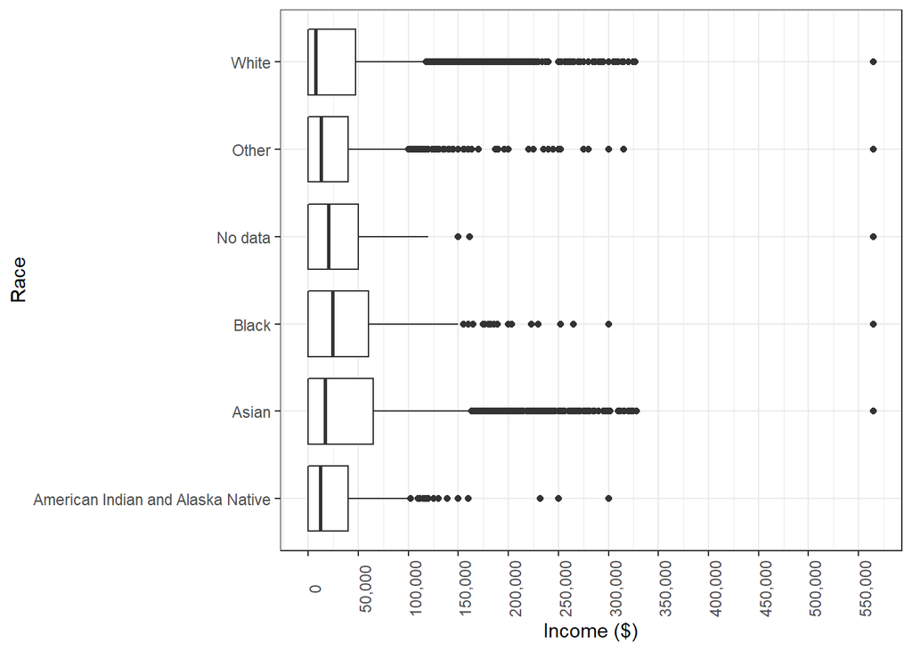

```r
ggplot(citizenship_data, aes(x = RACE, y = WAGP)) +
  geom_boxplot() +
  theme_bw() +
  theme(axis.text.x = element_text(angle = 90)) +
  scale_x_discrete(name = "Race") +
  scale_y_continuous(name = "Income ($)",
                     breaks = seq(0, 565000, by = 50000),
                     labels = paste(  prettyNum(seq(0, 565000, by = 50000),
                                              big.mark = ","))) +
  coord_flip()
```

### Race and Period of Naturalization

```r
anova_race_period_nat <- aov(years_to_nat ~ RACE, data = citizenship_data)

summary(anova_race_period_nat)
```

```
##                Df  Sum Sq Mean Sq F value              Pr(>F)
## RACE            5  516256  103251    1219 <0.0000000000000002 ***
## Residuals   51404 4355489      85
## ---
## Signif. codes:  0 '***' 0.001 '**' 0.01 '*' 0.05 '.' 0.1 ' ' 1
```

Running a Tukey’s Honestly Significant Test, since the p value is less than 0.05.

```r
differences <- TukeyHSD(anova_race_period_nat)

as_tibble(cbind(pair = row.names(differences$RACE),
                differences$RACE))
```

```
## # A tibble: 15 x 5
##    pair                   diff         lwr         upr         `p adj`
##    <chr>                  <chr>        <chr>       <chr>       <chr>
##  1 Asian-American Indian~ -6.69247557~ -8.0265183~ -5.3584328~ 0
##  2 Black-American Indian~ -4.71522378~ -6.3100794~ -3.1203681~ 0.00000000000006~
##  3 No data-American Indi~ -5.00953858~ -7.3398657~ -2.6792114~ 0.00000001349676~
##  4 Other-American Indian~ 1.485336128~ 0.12538047~ 2.84529178~ 0.02284938366754~
##  5 White-American Indian~ -1.29328974~ -2.6300166~ 0.04343719~ 0.06456714640984~
##  6 Black-Asian            1.977251780~ 1.07085949~ 2.88364406~ 0.00000000761821~
##  7 No data-Asian          1.682936987~ -0.2427855~ 3.60865947~ 0.12681538997332
##  8 Other-Asian            8.177811698~ 7.82079382~ 8.53482957~ 0
##  9 White-Asian            5.399185827~ 5.14458560~ 5.65378604~ 0
## 10 No data-Black          -0.29431479~ -2.4090964~ 1.82046691~ 0.998740519746809
## 11 Other-Black            6.200559918~ 5.25644322~ 7.14467660~ 0
## 12 White-Black            3.421934047~ 2.51159574~ 4.33227235~ 0.00000000000005~
## 13 Other-No data          6.494874711~ 4.55111123~ 8.43863818~ 0.00000000000004~
## 14 White-No data          3.716248840~ 1.78866590~ 5.64383177~ 0.00000058667941~
## 15 White-Other            -2.77862587~ -3.1455463~ -2.4117054~ 0
```

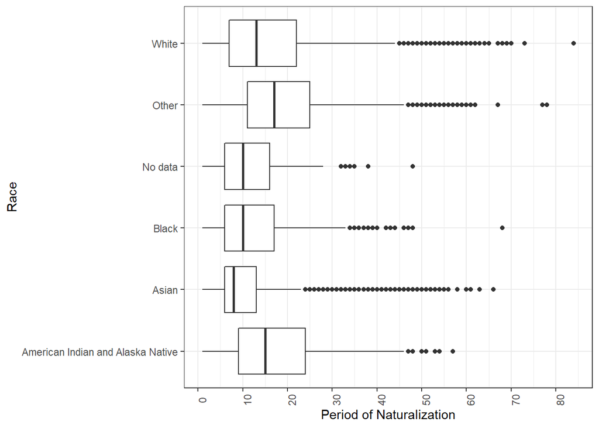

```r
ggplot(citizenship_data, aes(x = RACE, y = years_to_nat)) +
  geom_boxplot() +
  theme_bw() +
  theme(axis.text.x = element_text(angle = 90)) +
  scale_x_discrete(name = "Race") +
  scale_y_continuous(name = "Period of Naturalization",
                     breaks = seq(0, 100, by = 10),
                     labels = paste(  prettyNum(seq(0, 100, by = 10),
                                              big.mark = ","))) +
  coord_flip()
```

### Race and Age

```r
anova_race_age <- aov(AGEP ~ RACE, data = citizenship_data)

summary(anova_race_age)
```

```
##                Df   Sum Sq Mean Sq F value              Pr(>F)
## RACE            5    85100   17020   64.53 <0.0000000000000002 ***
## Residuals   51404 13558565     264
## ---
## Signif. codes:  0 '***' 0.001 '**' 0.01 '*' 0.05 '.' 0.1 ' ' 1
```

Running a Tukey’s Honestly Significant Test, since the p value is less than 0.05.

```r
differences <- TukeyHSD(anova_race_age)

as_tibble(cbind(pair = row.names(differences$RACE),
                differences$RACE))
```

```
## # A tibble: 15 x 5
##    pair                    diff         lwr         upr        `p adj`
##    <chr>                   <chr>        <chr>       <chr>      <chr>
##  1 Asian-American Indian ~ 1.130500345~ -1.2232377~ 3.4842384~ 0.745879341443258
##  2 Black-American Indian ~ -3.38055956~ -6.1944667~ -0.566652~ 0.00812585794822~
##  3 No data-American India~ -0.41664965~ -4.5281969~ 3.6948976~ 0.999731485925723
##  4 Other-American Indian ~ 0.181003717~ -2.2184542~ 2.5804616~ 0.999937347147746
##  5 White-American Indian ~ 3.092456021~ 0.73398204~ 5.4509300~ 0.00256870064095~
##  6 Black-Asian             -4.51105990~ -6.1102665~ -2.911853~ 0.00000000000009~
##  7 No data-Asian           -1.54715000~ -4.9448270~ 1.8505270~ 0.78652287905416
##  8 Other-Asian             -0.94949662~ -1.5794064~ -0.319586~ 0.00025195236302~
##  9 White-Asian             1.961955675~ 1.51274800~ 2.4111633~ 0
## 10 No data-Black           2.963909904~ -0.7673365~ 6.6951563~ 0.209094925217177
## 11 Other-Black             3.561563279~ 1.89579700~ 5.2273295~ 0.00000001660759~
## 12 White-Black             6.473015583~ 4.86684670~ 8.0791844~ 0
## 13 Other-No data           0.597653375~ -2.8318545~ 4.0271612~ 0.996307725740827
## 14 White-No data           3.509105679~ 0.10814616~ 6.9100651~ 0.03853106527533~
## 15 White-Other             2.911452304~ 2.26407076~ 3.5588338~ 0
```

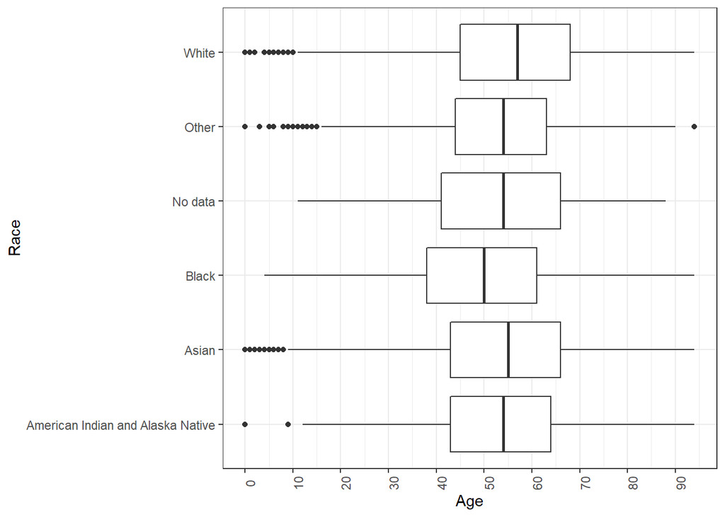

```r
ggplot(citizenship_data, aes(x = RACE, y = AGEP)) +
  geom_boxplot() +
  theme_bw() +
  theme(axis.text.x = element_text(angle = 90)) +
  scale_x_discrete(name = "Race") +
  scale_y_continuous(name = "Age",
                     breaks = seq(0, 100, by = 10),
                     labels = paste(  prettyNum(seq(0, 100, by = 10),
                                              big.mark = ","))) +
  coord_flip()
```

### Education and Income

```r
summary(WAGP)
```

```
##    Min. 1st Qu.  Median    Mean 3rd Qu.    Max.
##      -1       0   12500   38431   52000  565000
```

```r
anova_edu_income <- aov(WAGP ~ SCHL_label, data = citizenship_data)

summary(anova_edu_income)
```

```
##                Df          Sum Sq       Mean Sq F value              Pr(>F)
## SCHL_label     24  37057050106220 1544043754426   391.3 <0.0000000000000002 ***
## Residuals   51385 202758881627178    3945876844
## ---
## Signif. codes:  0 '***' 0.001 '**' 0.01 '*' 0.05 '.' 0.1 ' ' 1
```

Running a Tukey’s Honestly Significant Test, since the p value is less than 0.05.

```r
differences <- TukeyHSD(anova_edu_income)

as_tibble(cbind(pair = row.names(differences$SCHL_label),
                differences$SCHL_label))
```

```
## # A tibble: 300 x 5
##    pair                            diff       lwr       upr       `p adj`
##    <chr>                           <chr>      <chr>     <chr>     <chr>
##  1 12th grade - no diploma-1 or m~ -9829.973~ -15748.5~ -3911.44~ 0.00000036867~
##  2 Associate's degree-1 or more y~ 6764.7841~ 2047.703~ 11481.86~ 0.00004502339~
##  3 Bachelor's degree-1 or more ye~ 24460.140~ 20745.90~ 28174.37~ 0
##  4 Doctorate degree-1 or more yea~ 80172.355~ 72792.98~ 87551.72~ 0
##  5 GED or alternative credential-~ -4160.839~ -11728.4~ 3406.800~ 0.95178101012~
##  6 Grade 1-1 or more years of col~ -24033.83~ -46983.8~ -1083.84~ 0.02742861504~
##  7 Grade 10-1 or more years of co~ -15114.37~ -24651.2~ -5577.51~ 0.00000199823~
##  8 Grade 11-1 or more years of co~ -13347.97~ -22438.0~ -4257.89~ 0.00002278824~
##  9 Grade 2-1 or more years of col~ -21724.25~ -37437.8~ -6010.69~ 0.00012140371~
## 10 Grade 3-1 or more years of col~ -21521.25~ -32455.1~ -10587.4~ 0.00000000018~
## # ... with 290 more rows
```

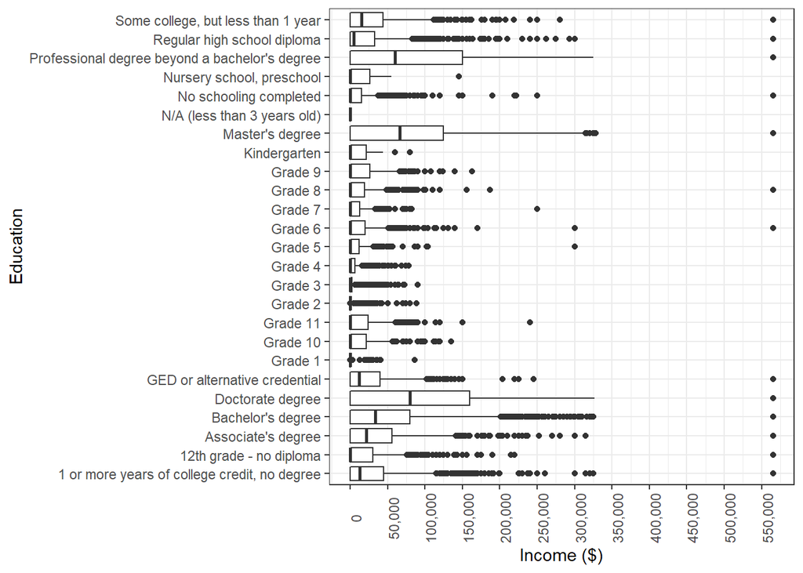

```r
ggplot(citizenship_data, aes(x = SCHL_label, y = WAGP)) +
  geom_boxplot() +
  theme_bw() +
  theme(axis.text.x = element_text(angle = 90)) +
  scale_x_discrete(name = "Education") +
  scale_y_continuous(name = "Income ($)",
                     breaks = seq(0, 565000, by = 50000),
                     labels = paste(  prettyNum(seq(0, 565000, by = 50000),
                                              big.mark = ","))) +
  coord_flip()
```

### Education and Period of Naturalization

```r
anova_edu_ped_nat <- aov(years_to_nat ~ SCHL_label, data = citizenship_data)

summary(anova_edu_ped_nat)
```

```
##                Df  Sum Sq Mean Sq F value              Pr(>F)
## SCHL_label     24  341709   14238   161.5 <0.0000000000000002 ***
## Residuals   51385 4530036      88
## ---
## Signif. codes:  0 '***' 0.001 '**' 0.01 '*' 0.05 '.' 0.1 ' ' 1
```

```r
differences <- TukeyHSD(anova_edu_ped_nat)

as_tibble(cbind(pair = row.names(differences$SCHL_label),
                differences$SCHL_label))
```

```
## # A tibble: 300 x 5
##    pair                           diff       lwr        upr       `p adj`
##    <chr>                          <chr>      <chr>      <chr>     <chr>
##  1 12th grade - no diploma-1 or ~ 1.7966532~ 0.9119961~ 2.681310~ 0.00000000003~
##  2 Associate's degree-1 or more ~ -0.834590~ -1.539663~ -0.12951~ 0.00379938114~
##  3 Bachelor's degree-1 or more y~ -2.330979~ -2.886154~ -1.77580~ 0
##  4 Doctorate degree-1 or more ye~ -0.779842~ -1.882853~ 0.323168~ 0.62885166983~
##  5 GED or alternative credential~ 1.6131390~ 0.4819860~ 2.744291~ 0.00005264562~
##  6 Grade 1-1 or more years of co~ 5.6558254~ 2.2254362~ 9.086214~ 0.00000048538~
##  7 Grade 10-1 or more years of c~ 1.9709644~ 0.5454678~ 3.396461~ 0.00012109517~
##  8 Grade 11-1 or more years of c~ 2.4375447~ 1.0788296~ 3.796259~ 0.00000001586~
##  9 Grade 2-1 or more years of co~ 8.5352636~ 6.1865203~ 10.88400~ 0
## 10 Grade 3-1 or more years of co~ 8.5842855~ 6.9499772~ 10.21859~ 0
## # ... with 290 more rows
```

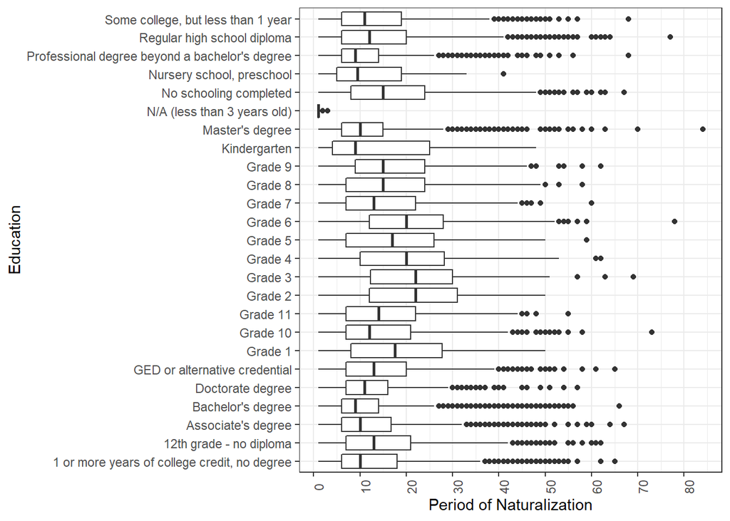

```r
ggplot(citizenship_data, aes(x = SCHL_label, y = years_to_nat)) +
  geom_boxplot() +
  theme_bw() +
  theme(axis.text.x = element_text(angle = 90)) +
  scale_x_discrete(name = "Education") +
  scale_y_continuous(name = "Period of Naturalization",
                     breaks = seq(0, 100, by = 10),
                     labels = paste(  prettyNum(seq(0, 100, by = 10),
                                              big.mark = ","))) +
  coord_flip()
```

### Employment and Income

```r
anova_work_income <- aov(WAGP ~ ESR_label, data = citizenship_data)

summary(anova_work_income)
```

```
##                Df          Sum Sq       Mean Sq F value              Pr(>F)
## ESR_label       6  48331230840802 8055205140134    2162 <0.0000000000000002 ***
## Residuals   51403 191484700892626    3725165864
## ---
## Signif. codes:  0 '***' 0.001 '**' 0.01 '*' 0.05 '.' 0.1 ' ' 1
```

Running a Tukey’s Honestly Significant Test.

```r
differences <- TukeyHSD(anova_work_income)

as_tibble(cbind(pair = row.names(differences$ESR_label),
                differences$ESR_label))
```

```
## # A tibble: 21 x 5
##    pair                            diff       lwr       upr       `p adj`
##    <chr>                           <chr>      <chr>     <chr>     <chr>
##  1 Armed forces, with a job but n~ -2917.475~ -183737.~ 177902.1~ 0.99999999901~
##  2 Civilian employed, at work-Arm~ 17701.031~ -60.9511~ 35463.01~ 0.05147458502~
##  3 Civilian employed, with a job ~ -4377.298~ -23156.4~ 14401.88~ 0.99333262964~
##  4 N/A (less than 16 years old)-A~ -46918.27~ -66727.5~ -27108.9~ 0.00000000006~
##  5 Not in labor force-Armed force~ -45523.34~ -63300.6~ -27746.0~ 0.00000000000~
##  6 Unemployed-Armed forces, at wo~ -33209.01~ -51721.5~ -14696.5~ 0.00000256313~
##  7 Civilian employed, at work-Arm~ 20618.506~ -159332.~ 200569.7~ 0.99988212466~
##  8 Civilian employed, with a job ~ -1459.822~ -181514.~ 178594.6~ 0.99999999998~
##  9 N/A (less than 16 years old)-A~ -44000.80~ -224165.~ 136164.0~ 0.99142855486~
## 10 Not in labor force-Armed force~ -42605.86~ -222558.~ 137346.8~ 0.99274570511~
## # ... with 11 more rows
```

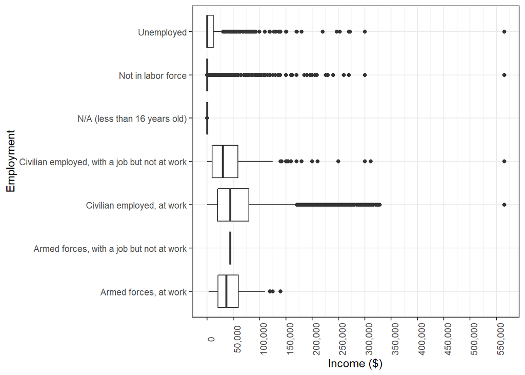

```r
ggplot(citizenship_data, aes(x = ESR_label, y = WAGP)) +
  geom_boxplot() +
  theme_bw() +
  theme(axis.text.x = element_text(angle=90)) +
  scale_x_discrete(name = "Employment") +
   scale_y_continuous(name = "Income ($)",
                     breaks = seq(0, 565000, by = 50000),
                     labels = paste(  prettyNum(seq(0, 565000, by = 50000),
                                              big.mark = ","))) +
  coord_flip()
```

### Employment and Period of Naturalization

```r
anova_work_nat <- aov(years_to_nat ~ ESR_label, data = citizenship_data)
summary(anova_work_nat)
```

```
##                Df  Sum Sq Mean Sq F value              Pr(>F)
## ESR_label       6   67323   11221     120 <0.0000000000000002 ***
## Residuals   51403 4804421      93
## ---
## Signif. codes:  0 '***' 0.001 '**' 0.01 '*' 0.05 '.' 0.1 ' ' 1
```

Running a Tukey’s Honestly Significant Test.

```r
differences <- TukeyHSD(anova_work_nat)

as_tibble(cbind(pair = row.names(differences$ESR_label),
                differences$ESR_label))
```

```
## # A tibble: 21 x 5
##    pair                            diff       lwr       upr       `p adj`
##    <chr>                           <chr>      <chr>     <chr>     <chr>
##  1 Armed forces, with a job but n~ 2.0291262~ -26.6125~ 30.67083~ 0.99999310959~
##  2 Civilian employed, at work-Arm~ 5.1344990~ 2.321011~ 7.947986~ 0.00000154871~
##  3 Civilian employed, with a job ~ 5.2182515~ 2.243639~ 8.192863~ 0.00000481136~
##  4 N/A (less than 16 years old)-A~ -2.513042~ -5.65082~ 0.624742~ 0.21521961520~
##  5 Not in labor force-Armed force~ 6.8569988~ 4.041087~ 9.672910~ 0.00000000001~
##  6 Unemployed-Armed forces, at wo~ 5.3108409~ 2.378474~ 8.243207~ 0.00000194037~
##  7 Civilian employed, at work-Arm~ 3.1053728~ -25.3987~ 31.60954~ 0.99991228478~
##  8 Civilian employed, with a job ~ 3.1891252~ -25.3313~ 31.70964~ 0.99989781235~
##  9 N/A (less than 16 years old)-A~ -4.542168~ -33.0801~ 23.99583~ 0.99920829971~
## 10 Not in labor force-Armed force~ 4.8278726~ -23.6765~ 33.33227~ 0.99887131563~
## # ... with 11 more rows
```

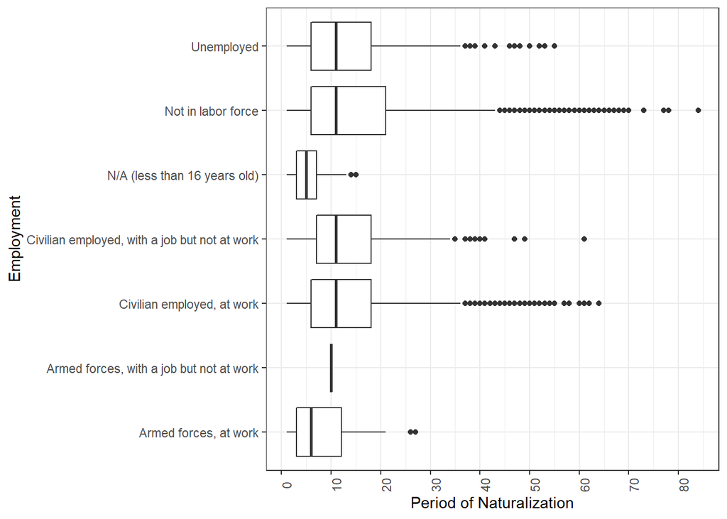

```r
ggplot(citizenship_data, aes(x = ESR_label, y = years_to_nat)) +
  geom_boxplot() +
  theme_bw() +
  theme(axis.text.x = element_text(angle=90)) +
  scale_x_discrete(name = "Employment") +
   scale_y_continuous(name = "Period of Naturalization",
                     breaks = seq(0, 100, by = 10),
                     labels = paste(  prettyNum(seq(0, 100, by = 10),
                                              big.mark = ","))) +
  coord_flip()
```

## Chi-square tests

### Race and Employment

```r
chi_sq_race_work <- chisq.test(citizenship_data$RACE, citizenship_data$ESR_label)
chi_sq_race_work
```

```
##
##  Pearson's Chi-squared test
##
## data:  citizenship_data$RACE and citizenship_data$ESR_label
## X-squared = 395.05, df = 30, p-value < 0.00000000000000022
```

```r
chi_sq_race_work$observed
```

```
##                                    citizenship_data$ESR_label
## citizenship_data$RACE               Armed forces, at work
##   American Indian and Alaska Native                     0
##   Asian                                                42
##   Black                                                20
##   No data                                               0
##   Other                                                14
##   White                                                27
##                                    citizenship_data$ESR_label
## citizenship_data$RACE               Armed forces, with a job but not at work
##   American Indian and Alaska Native                                        0
##   Asian                                                                    1
##   Black                                                                    0
##   No data                                                                  0
##   Other                                                                    0
##   White                                                                    0
##                                    citizenship_data$ESR_label
## citizenship_data$RACE               Civilian employed, at work
##   American Indian and Alaska Native                        231
##   Asian                                                  13932
##   Black                                                    546
##   No data                                                  112
##   Other                                                   4058
##   White                                                  10398
##                                    citizenship_data$ESR_label
## citizenship_data$RACE               Civilian employed, with a job but not at work
##   American Indian and Alaska Native                                             2
##   Asian                                                                       379
##   Black                                                                        19
##   No data                                                                       7
##   Other                                                                       151
##   White                                                                       288
##                                    citizenship_data$ESR_label
## citizenship_data$RACE               N/A (less than 16 years old)
##   American Indian and Alaska Native                            9
##   Asian                                                      206
##   Black                                                       21
##   No data                                                      2
##   Other                                                       43
##   White                                                      134
##                                    citizenship_data$ESR_label
## citizenship_data$RACE               Not in labor force Unemployed
##   American Indian and Alaska Native                142          9
##   Asian                                           8839        471
##   Black                                            239         23
##   No data                                           61          5
##   Other                                           2540        170
##   White                                           7804        465
```

```r
chi_sq_race_work$expected
```

```
##                                    citizenship_data$ESR_label
## citizenship_data$RACE               Armed forces, at work
##   American Indian and Alaska Native             0.7873760
##   Asian                                        47.8235752
##   Black                                         1.7390391
##   No data                                       0.3746547
##   Other                                        13.9764248
##   White                                        38.2989302
##                                    citizenship_data$ESR_label
## citizenship_data$RACE               Armed forces, with a job but not at work
##   American Indian and Alaska Native                              0.007644427
##   Asian                                                          0.464306555
##   Black                                                          0.016883875
##   No data                                                        0.003637425
##   Other                                                          0.135693445
##   White                                                          0.371834273
##                                    citizenship_data$ESR_label
## citizenship_data$RACE               Civilian employed, at work
##   American Indian and Alaska Native                   223.8059
##   Asian                                             13593.5030
##   Black                                               494.3092
##   No data                                             106.4929
##   Other                                              3972.6970
##   White                                             10886.1920
##                                    citizenship_data$ESR_label
## citizenship_data$RACE               Civilian employed, with a job but not at work
##   American Indian and Alaska Native                                      6.467185
##   Asian                                                                392.803346
##   Black                                                                 14.283758
##   No data                                                                3.077261
##   Other                                                                114.796654
##   White                                                                314.571795
##                                    citizenship_data$ESR_label
## citizenship_data$RACE               N/A (less than 16 years old)
##   American Indian and Alaska Native                     3.172437
##   Asian                                               192.687220
##   Black                                                 7.006808
##   No data                                               1.509531
##   Other                                                56.312780
##   White                                               154.311223
##                                    citizenship_data$ESR_label
## citizenship_data$RACE               Not in labor force Unemployed
##   American Indian and Alaska Native          150.02188   8.737580
##   Asian                                     9112.01614 530.702393
##   Black                                      331.34604  19.298269
##   No data                                     71.38446   4.157576
##   Other                                     2662.98386 155.097607
##   White                                     7297.24762 425.006575
```

```r
c_diff_rw <- chi_sq_race_work$observed - chi_sq_race_work$expected
c_diff_rw_data <- as.data.frame(c_diff_rw)
```

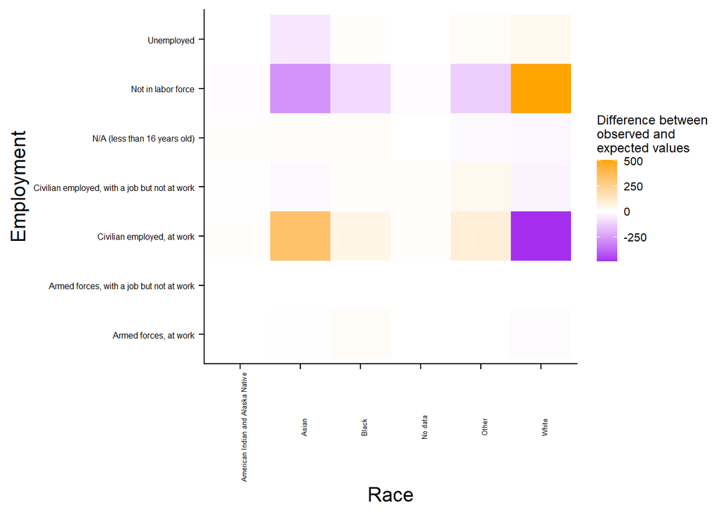

```r
c_diff_heatmap_rw <- ggplot(c_diff_rw_data,
                         aes(x = citizenship_data.RACE,
                             y = citizenship_data.ESR_label,
                             fill = Freq)) +
  geom_tile() +
  scale_x_discrete(name = "Race") +
  scale_y_discrete(name = "Employment") +
  theme_cowplot() +
 theme(legend.key.size =  unit(0.5, "cm"),
        plot.title = element_text(hjust = 2),
        axis.text.x = element_text(angle = 90, size = 5),
        axis.text.y = element_text(size = 6),
        legend.text = element_text(size = 8),
        legend.title = element_text(size = 9)) +
  scale_fill_gradient2(name = "Difference between \nobserved and \nexpected values",
                       midpoint = 0,
                       low = "purple",
                       mid = "white",
                       high = "orange",
                       space = "Lab")
c_diff_heatmap_rw
```

### Race and Education

```r
chi_sq_race_edu <- chisq.test(citizenship_data$RACE, citizenship_data$SCHL_label)
chi_sq_race_edu
```

```
##
##  Pearson's Chi-squared test
##
## data:  citizenship_data$RACE and citizenship_data$SCHL_label
## X-squared = 6595.9, df = 120, p-value < 0.00000000000000022
```

```r
chi_sq_race_edu$observed
```

```
##                                    citizenship_data$SCHL_label
## citizenship_data$RACE               1 or more years of college credit, no degree
##   American Indian and Alaska Native                                           52
##   Asian                                                                     2581
##   Black                                                                      121
##   No data                                                                     28
##   Other                                                                      766
##   White                                                                     2255
##                                    citizenship_data$SCHL_label
## citizenship_data$RACE               12th grade - no diploma Associate's degree
##   American Indian and Alaska Native                      14                 29
##   Asian                                                 798               2015
##   Black                                                  27                105
##   No data                                                 8                 20
##   Other                                                 376                362
##   White                                                 813               1483
##                                    citizenship_data$SCHL_label
## citizenship_data$RACE               Bachelor's degree Doctorate degree
##   American Indian and Alaska Native                48                2
##   Asian                                          7469              645
##   Black                                           192               20
##   No data                                          20                0
##   Other                                           500               18
##   White                                          3010              479
##                                    citizenship_data$SCHL_label
## citizenship_data$RACE               GED or alternative credential Grade 1
##   American Indian and Alaska Native                            13       0
##   Asian                                                       264      18
##   Black                                                        19       0
##   No data                                                       9       2
##   Other                                                       260      24
##   White                                                       531      58
##                                    citizenship_data$SCHL_label
## citizenship_data$RACE               Grade 10 Grade 11 Grade 2 Grade 3 Grade 4
##   American Indian and Alaska Native        3        7       6       7       2
##   Asian                                  216      176      43      81      56
##   Black                                    3        9       2       2       5
##   No data                                  8        3       0       2       0
##   Other                                  124      198      72     163      79
##   White                                  291      325      99     223     158
```

[output cut: 49 more lines]

```
## citizenship_data$RACE               Regular high school diploma
##   American Indian and Alaska Native                          64
##   Asian                                                    2868
##   Black                                                     112
##   No data                                                    47
##   Other                                                    1528
##   White                                                    3248
##                                    citizenship_data$SCHL_label
## citizenship_data$RACE               Some college, but less than 1 year
##   American Indian and Alaska Native                                 20
##   Asian                                                            939
##   Black                                                             52
##   No data                                                           20
##   Other                                                            340
##   White                                                           1004
```

```r
chi_sq_race_edu$expected
```

```
##                                    citizenship_data$SCHL_label
## citizenship_data$RACE               1 or more years of college credit, no degree
##   American Indian and Alaska Native                                     44.36061
##   Asian                                                               2694.37094
##   Black                                                                 97.97713
##   No data                                                               21.10798
##   Other                                                                787.42906
##   White                                                               2157.75429
##                                    citizenship_data$SCHL_label
## citizenship_data$RACE               12th grade - no diploma Associate's degree
##   American Indian and Alaska Native               15.564054           30.68473
##   Asian                                          945.328146         1863.72651
##   Black                                           34.375569           67.77187
##   No data                                          7.405797           14.60062
##   Other                                          276.271854          544.67349
##   White                                          757.054581         1492.54277
##                                    citizenship_data$SCHL_label
## citizenship_data$RACE               Bachelor's degree Doctorate degree
##   American Indian and Alaska Native          85.91572         8.898113
##   Asian                                    5218.34137       540.452830
##   Black                                     189.75787        19.652830
##   No data                                    40.88102         4.233962
##   Other                                    1525.05863       157.947170
##   White                                    4179.04540       432.815094
##                                    citizenship_data$SCHL_label
## citizenship_data$RACE               GED or alternative credential    Grade 1
##   American Indian and Alaska Native                      8.378292  0.7797316
##   Asian                                                508.879984 47.3592686
##   Black                                                 18.504727  1.7221552
##   No data                                                3.986617  0.3710173
##   Other                                                148.720016 13.8407314
##   White                                                407.530364 37.9270959
##                                    citizenship_data$SCHL_label
## citizenship_data$RACE                 Grade 10   Grade 11     Grade 2
##   American Indian and Alaska Native   4.930656   5.488699   1.6970628
##   Asian                             299.477728 333.372107 103.0760552
##   Black                              10.890099  12.122622   3.7482202
##   No data                             2.346139   2.611671   0.8075083
##   Other                              87.522272  97.427893  30.1239448
##   White                             239.833106 266.977008  82.5472087
```

[output cut: 57 more lines]

```
## citizenship_data$RACE               Regular high school diploma
##   American Indian and Alaska Native                    60.13871
##   Asian                                              3652.69967
##   Black                                               132.82544
##   No data                                              28.61562
##   Other                                              1067.50033
##   White                                              2925.22023
##                                    citizenship_data$SCHL_label
## citizenship_data$RACE               Some college, but less than 1 year
##   American Indian and Alaska Native                          18.155514
##   Asian                                                    1102.728068
##   Black                                                      40.099202
##   No data                                                     8.638883
##   Other                                                     322.271932
##   White                                                     883.106400
```

```r
c_diff_re <- chi_sq_race_edu$observed - chi_sq_race_edu$expected
c_diff_re_data <- as.data.frame(c_diff_re)
```

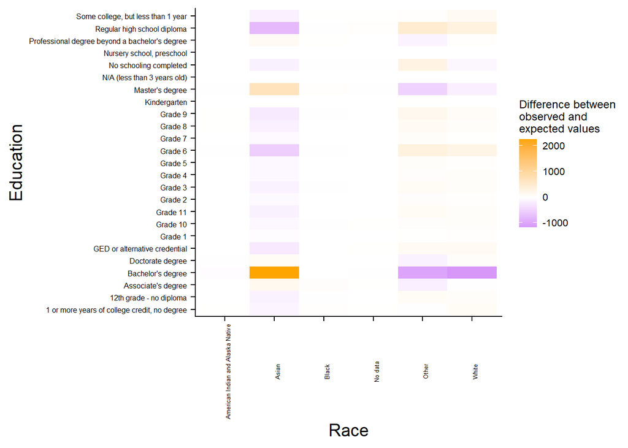

```r
c_diffheatmap_re <- ggplot(c_diff_re_data,
                         aes(x = citizenship_data.RACE,
                             y = citizenship_data.SCHL_label,
                             fill = Freq)) +
  geom_tile() +
  scale_x_discrete(name = "Race") +
  scale_y_discrete(name = "Education") +
  theme_cowplot() +
  theme(legend.key.size =  unit(0.5, "cm"),
        plot.title = element_text(hjust = 2),
        axis.text.x = element_text(angle = 90, size = 5),
        axis.text.y = element_text(size = 6),
        legend.text = element_text(size = 8),
        legend.title = element_text(size = 9)) +
  scale_fill_gradient2(name = "Difference between \nobserved and \nexpected values",
                       midpoint = 0,
                       low = "purple",
                       mid = "white",
                       high = "orange",
                       space = "Lab")
c_diffheatmap_re
```